# Chapter 8 - Exponential smoothing

R. Hyndman/R. J. Serrano

7/30/2022

# Exponential smoothing

# Historical perspective

- Developed in the 1950s and 1960s as methods (algorithms) to produce point forecasts.
- Combine a “level”, “trend” (slope) and “seasonal” component to describe a time series.
- The rate of change of the components are controlled by “smoothing parameters”: $\alpha$, $\beta$ and $\gamma$ respectively.
- Need to choose best values for the smoothing parameters (and initial states).
- Equivalent ETS state space models developed in the 1990s and 2000s.

# Big idea: control the rate of change

$\alpha$ controls the flexibility of the **level**

- If $\alpha = 0$, the level never updates (mean)
- If $\alpha = 1$, the level updates completely (naive)

$\beta$ controls the flexibility of the **trend**

- If $\beta = 0$, the trend is linear
- If $\beta = 1$, the trend changes suddenly every observation

$\gamma$ controls the flexibility of the **seasonality**

- If $\gamma = 0$, the seasonality is fixed (seasonal means)
- If $\gamma = 1$, the seasonality updates completely (seasonal naive)

# A model for levels, trends, and seasonalities

We want a model that captures the level ($\ell_t$), trend ($b_t$) and seasonality ($s_t$).

# ETS models

Additive (`"A"`) or multiplicative (`"M"`)

None (`"N"`), additive (`"A"`), multiplicative (`"M"`), or damped (`"Ad"` or `"Md"`).

None (`"N"`), additive (`"A"`) or multiplicative (`"M"`)

# Simple exponential smoothing

# Simple methods

Time series $y_1,y_2,\dots,y_T$.

- Want something in between these methods.
- Most recent data should have more weight.

# Simple Exponential Smoothing

# Simple Exponential Smoothing

[video not shown]

# Simple Exponential Smoothing

- $\ell_t$ is the level (or the smoothed value) of the series at time t.
- $\pred{y}{t+1}{t} = \alpha y_t + (1-\alpha) \pred{y}{t}{t-1}$

Iterate to get exponentially weighted moving average form.

# Optimising smoothing parameters

- Need to choose best values for $\alpha$ and $\ell_0$.
- Similarly to regression, choose optimal parameters by minimising SSE:
  $$\text{SSE}=\sum_{t=1}^T(y_t - \pred{y}{t}{t-1})^2.$$
- Unlike regression there is no closed form solution — use numerical optimization.
- For Algerian Exports example:
  - $\hat\alpha = 0.8400$
  - $\hat\ell_0 = 39.54$

# Simple Exponential Smoothing

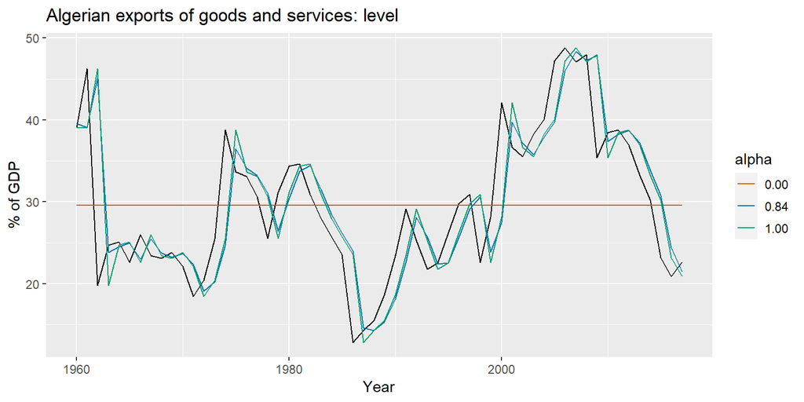

# Models and methods

### Methods

- Algorithms that return point forecasts.

### Models

- Generate same point forecasts but can also generate forecast distributions.
- A stochastic (or random) data generating process that can generate an entire forecast distribution.
- Allow for “proper” model selection.

# ETS(A,N,N): SES with additive errors

Forecast error: $e_t = y_t - \pred{y}{t}{t-1} = y_t - \ell_{t-1}$.

Specify probability distribution for $e_t$, we assume $e_t = \varepsilon_t\sim\text{NID}(0,\sigma^2)$.

# ETS(A,N,N): SES with additive errors

where $\varepsilon_t\sim\text{NID}(0,\sigma^2)$.

- “innovations” or “single source of error” because equations have the same error process, $\varepsilon_t$.
- Measurement equation: relationship between observations and states.
- State equation(s): evolution of the state(s) through time.

# ETS(M,N,N): SES with multiplicative errors.

- Specify relative errors $\varepsilon_t=\frac{y_t-\pred{y}{t}{t-1}}{\pred{y}{t}{t-1}}\sim \text{NID}(0,\sigma^2)$
- Substituting $\pred{y}{t}{t-1}=\ell_{t-1}$ gives:
  - $y_t = \ell_{t-1}+\ell_{t-1}\varepsilon_t$
  - $e_t = y_t - \pred{y}{t}{t-1} = \ell_{t-1}\varepsilon_t$
- Models with additive and multiplicative errors with the same parameters generate the same point forecasts but different prediction intervals.

# ETS(A,N,N): Specifying the model

```r
ETS(y ~ error("A") + trend("N") + season("N"))
```

By default, an optimal value for $\alpha$ and $\ell_0$ is used.

$\alpha$ can be chosen manually in `trend()`.

```r
trend("N", alpha = 0.5)
trend("N", alpha_range = c(0.2, 0.8))
```

# Example: Algerian Exports

```r
algeria_economy <- global_economy %>%
  filter(Country == "Algeria")

fit <- algeria_economy %>%
  model(ANN = ETS(Exports ~ error("A") + trend("N") + season("N")))
report(fit)
```

```
## Series: Exports
## Model: ETS(A,N,N)
##   Smoothing parameters:
##     alpha = 0.84
##
##   Initial states:
##  l[0]
##  39.5
##
##   sigma^2:  35.6
##
##  AIC AICc  BIC
##  447  447  453
```

# Example: Algerian Exports

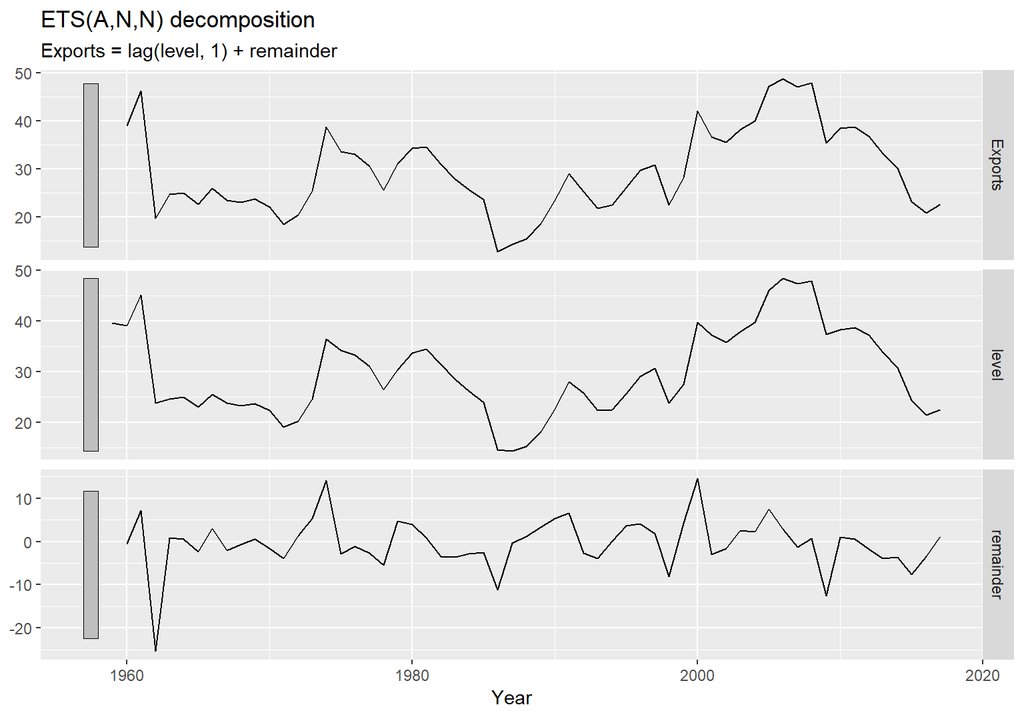

```r
components(fit) %>% autoplot()
```

# Example: Algerian Exports

```r
components(fit) %>%
  left_join(fitted(fit), by = c("Country", ".model", "Year"))
```

| Country | .model | Year | Exports | level | remainder | .fitted |
| --- | --- | --- | --- | --- | --- | --- |
| Algeria | ANN | 1959 | NA | 39.5 | NA | NA |
| Algeria | ANN | 1960 | 39.0 | 39.1 | -0.496 | 39.5 |
| Algeria | ANN | 1961 | 46.2 | 45.1 | 7.122 | 39.1 |
| Algeria | ANN | 1962 | 19.8 | 23.8 | -25.311 | 45.1 |
| Algeria | ANN | 1963 | 24.7 | 24.6 | 0.841 | 23.8 |
| Algeria | ANN | 1964 | 25.1 | 25.0 | 0.534 | 24.6 |
| Algeria | ANN | 1965 | 22.6 | 23.0 | -2.395 | 25.0 |
| Algeria | ANN | 1966 | 26.0 | 25.5 | 2.999 | 23.0 |
| Algeria | ANN | 1967 | 23.4 | 23.8 | -2.072 | 25.5 |
| Algeria | ANN | 1968 | 23.1 | 23.2 | -0.630 | 23.8 |

[output cut: 49 more lines]

# Example: Algerian Exports

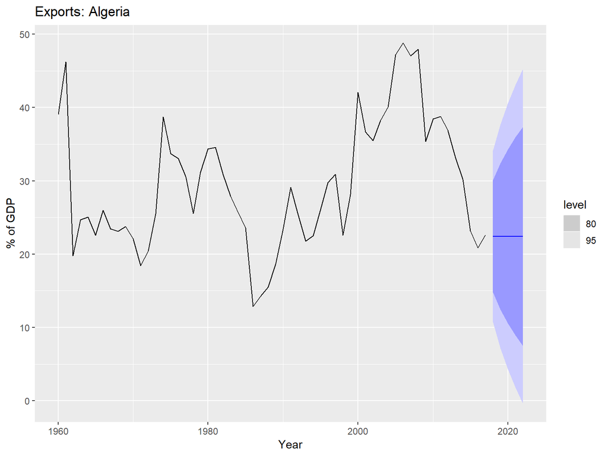

```r
fit %>%
  forecast(h = 5) %>%
  autoplot(algeria_economy) +
  labs(y = "% of GDP", title = "Exports: Algeria")
```

# Models with trend

# Holt’s linear trend

- Two smoothing parameters $\alpha$ and $\beta^*$ ($0\le\alpha,\beta^*\le1$).
- $\ell_t$ level: weighted average between $y_t$ and one-step ahead forecast for time $t$, $(\ell_{t-1} + b_{t-1}=\pred{y}{t}{t-1})$
- $b_t$ slope: weighted average of $(\ell_{t} - \ell_{t-1})$ and $b_{t-1}$, current and previous estimate of slope.
- Choose $\alpha, \beta^*, \ell_0, b_0$ to minimise SSE.

# ETS(A,A,N)

Holt’s linear method with additive errors.

- Assume $\varepsilon_t=y_t-\ell_{t-1}-b_{t-1} \sim \text{NID}(0,\sigma^2)$.
- Substituting into the error correction equations for Holt’s linear method
  $$\begin{align*}
  y_t&=\ell_{t-1}+b_{t-1}+\varepsilon_t\\
  \ell_t&=\ell_{t-1}+b_{t-1}+\alpha \varepsilon_t\\
  b_t&=b_{t-1}+\alpha\beta^* \varepsilon_t
  \end{align*}$$
- For simplicity, set $\beta=\alpha \beta^*$.

# Exponential smoothing: trend/slope

[video not shown]

# ETS(M,A,N)

Holt’s linear method with multiplicative errors.

- Assume $\varepsilon_t=\frac{y_t-(\ell_{t-1}+b_{t-1})}{(\ell_{t-1}+b_{t-1})}$
- Following a similar approach as above, the innovations state space model underlying Holt’s linear method with multiplicative errors is specified as
  $$\begin{align*}
  y_t&=(\ell_{t-1}+b_{t-1})(1+\varepsilon_t)\\
  \ell_t&=(\ell_{t-1}+b_{t-1})(1+\alpha \varepsilon_t)\\
  b_t&=b_{t-1}+\beta(\ell_{t-1}+b_{t-1}) \varepsilon_t
  \end{align*}$$
  where again $\beta=\alpha \beta^*$ and $\varepsilon_t \sim \text{NID}(0,\sigma^2)$.

# ETS(A,A,N): Specifying the model

```r
ETS(y ~ error("A") + trend("A") + season("N"))
```

By default, optimal values for $\beta$ and $b_0$ are used.

$\beta$ can be chosen manually in `trend()`.

```r
trend("A", beta = 0.004)
trend("A", beta_range = c(0, 0.1))
```

# Example: Australian population

```r
aus_economy <- global_economy %>% filter(Code == "AUS") %>%
  mutate(Pop = Population / 1e6)
fit <- aus_economy %>%
  model(AAN = ETS(Pop ~ error("A") + trend("A") + season("N")))
report(fit)
```

```
## Series: Pop
## Model: ETS(A,A,N)
##   Smoothing parameters:
##     alpha = 1
##     beta  = 0.327
##
##   Initial states:
##  l[0]  b[0]
##  10.1 0.222
##
##   sigma^2:  0.0041
##
##   AIC  AICc   BIC
## -77.0 -75.8 -66.7
```

# Example: Australian population

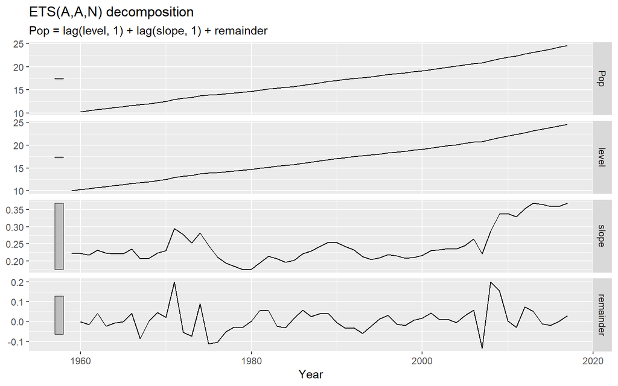

```r
components(fit) %>% autoplot()
```

# Example: Australian population

```r
components(fit) %>%
  left_join(fitted(fit), by = c("Country", ".model", "Year"))
```

| Country | .model | Year | Pop | level | slope | remainder | .fitted |
| --- | --- | --- | --- | --- | --- | --- | --- |
| Australia | AAN | 1959 | NA | 10.1 | 0.222 | NA | NA |
| Australia | AAN | 1960 | 10.3 | 10.3 | 0.222 | -0.000145 | 10.3 |
| Australia | AAN | 1961 | 10.5 | 10.5 | 0.217 | -0.015911 | 10.5 |
| Australia | AAN | 1962 | 10.7 | 10.7 | 0.231 | 0.041761 | 10.7 |
| Australia | AAN | 1963 | 10.9 | 11.0 | 0.223 | -0.022874 | 11.0 |
| Australia | AAN | 1964 | 11.2 | 11.2 | 0.221 | -0.006409 | 11.2 |
| Australia | AAN | 1965 | 11.4 | 11.4 | 0.221 | -0.000314 | 11.4 |
| Australia | AAN | 1966 | 11.7 | 11.7 | 0.235 | 0.041789 | 11.6 |
| Australia | AAN | 1967 | 11.8 | 11.8 | 0.206 | -0.086856 | 11.9 |
| Australia | AAN | 1968 | 12.0 | 12.0 | 0.208 | 0.003501 | 12.0 |

[output cut: 49 more lines]

# Example: Australian population

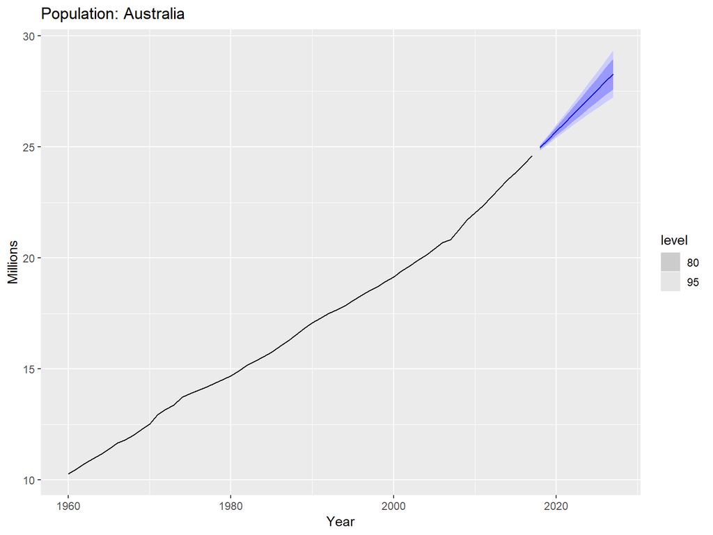

```r
fit %>%
  forecast(h = 10) %>%
  autoplot(aus_economy) +
  labs(y = "Millions", title = "Population: Australia")
```

# Damped trend method

- Damping parameter $0<\phi<1$.
- If $\phi=1$, identical to Holt’s linear trend.
- As $h\rightarrow\infty$, $\pred{y}{T+h}{T}\rightarrow \ell_T+\phi b_T/(1-\phi)$.
- Short-run forecasts trended, long-run forecasts constant.

# Example: Australian population

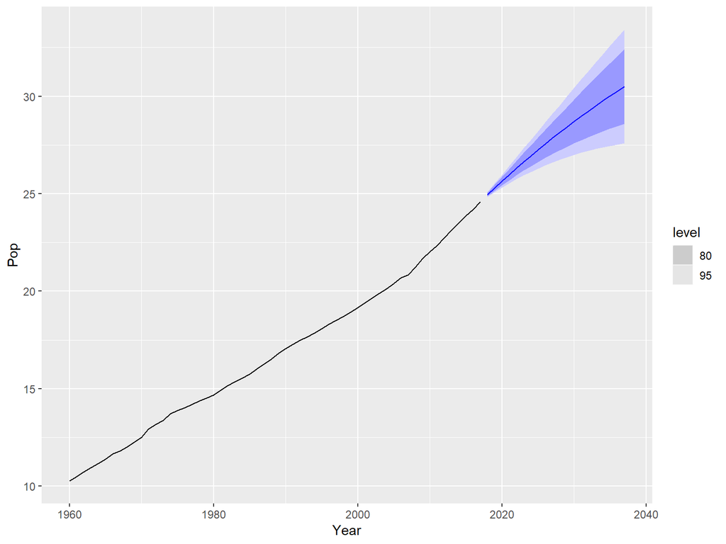

```r
aus_economy %>%
  model(holt = ETS(Pop ~ error("A") + trend("Ad") + season("N"))) %>%
  forecast(h = 20) %>%
  autoplot(aus_economy)
```

# Example: Australian population

```r
fit <- aus_economy %>%
  filter(Year <= 2010) %>%
  model(
    ses = ETS(Pop ~ error("A") + trend("N") + season("N")),
    holt = ETS(Pop ~ error("A") + trend("A") + season("N")),
    damped = ETS(Pop ~ error("A") + trend("Ad") + season("N"))
  )
```

```r
tidy(fit)
accuracy(fit)
```

# Example: Australian population

| term | SES | Linear trend | Damped trend |
| --- | --- | --- | --- |
| $\alpha$ | 1.00 | 1.00 | 1.00 |
| $\beta^*$ |  | 0.30 | 0.40 |
| $\phi$ |  |  | 0.98 |
| NA |  | 0.22 | 0.25 |
| NA | 10.28 | 10.05 | 10.04 |
| Training RMSE | 0.24 | 0.06 | 0.07 |
| Test RMSE | 1.63 | 0.15 | 0.21 |
| Test MASE | 6.18 | 0.55 | 0.75 |
| Test MAPE | 6.09 | 0.55 | 0.74 |
| Test MAE | 1.45 | 0.13 | 0.18 |

# Models with seasonality

# Holt-Winters additive method

Holt and Winters extended Holt’s method to capture seasonality.

- $k=$ integer part of $(h-1)/m$. Ensures estimates from the final year are used for forecasting.
- Parameters: $0\le \alpha\le 1$, $0\le \beta^*\le 1$, $0\le \gamma\le 1-\alpha$ and $m=$ period of seasonality (e.g. $m=4$ for quarterly data).

# Holt-Winters additive method

- Seasonal component is usually expressed as $s_{t} = \gamma^* (y_{t}-\ell_{t})+ (1-\gamma^*)s_{t-m}.$
- Substitute in for $\ell_t$: $s_{t} = \gamma^*(1-\alpha) (y_{t}-\ell_{t-1}-b_{t-1})+ [1-\gamma^*(1-\alpha)]s_{t-m}$
- We set $\gamma=\gamma^*(1-\alpha)$.
- The usual parameter restriction is $0\le\gamma^*\le1$, which translates to $0\le\gamma\le(1-\alpha)$.

# Exponential smoothing: seasonality

[video not shown]

# ETS(A,A,A)

Holt-Winters additive method with additive errors.

- Forecast errors: $\varepsilon_{t} = y_t - \hat{y}_{t|t-1}$
- $k$ is integer part of $(h-1)/m$.

# Holt-Winters multiplicative method

Seasonal variations change in proportion to the level of the series.

- $k$ is integer part of $(h-1)/m$.
- Additive method: $s_t$ in absolute terms — within each year $\sum_i s_i \approx 0$.
- Multiplicative method: $s_t$ in relative terms — within each year $\sum_i s_i \approx m$.

# ETS(M,A,M)

Holt-Winters multiplicative method with multiplicative errors.

- Forecast errors: $\varepsilon_{t} = (y_t - \hat{y}_{t|t-1})/\hat{y}_{t|t-1}$
- $k$ is integer part of $(h-1)/m$.

# Example: Australian holiday tourism

```r
aus_holidays <- tourism %>%
  filter(Purpose == "Holiday") %>%
  summarise(Trips = sum(Trips))
fit <- aus_holidays %>%
  model(
    additive = ETS(Trips ~ error("A") + trend("A") + season("A")),
    multiplicative = ETS(Trips ~ error("M") + trend("A") + season("M"))
  )
fc <- fit %>% forecast()
```

# Example: Australian holiday tourism

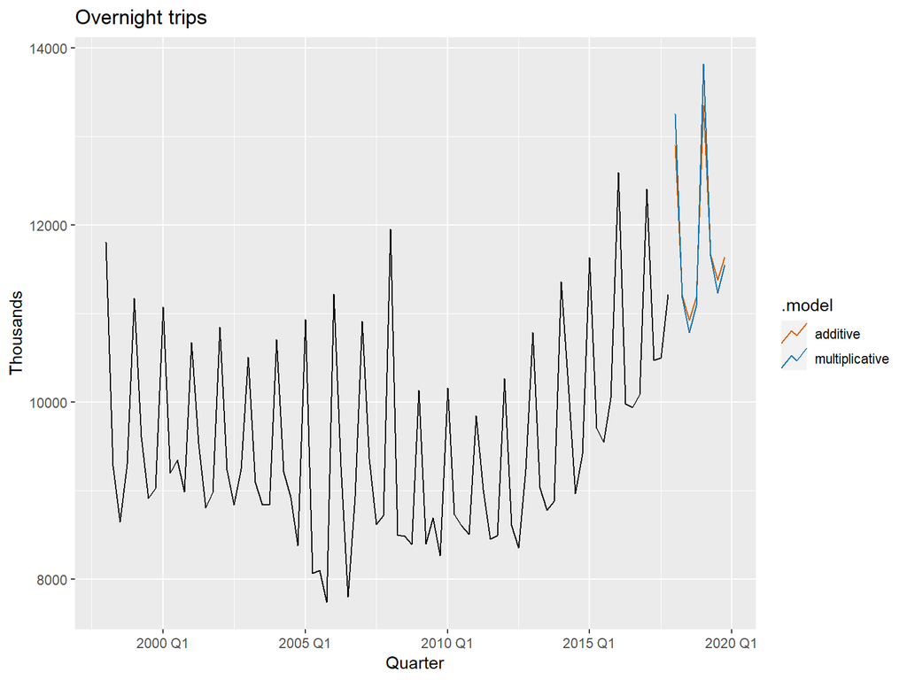

```r
fc %>%
  autoplot(aus_holidays, level = NULL) +
  labs(y = "Thousands", title = "Overnight trips")
```

# Estimated components

```r
components(fit)
```

| .model | Quarter | Trips | level | slope | season | remainder |
| --- | --- | --- | --- | --- | --- | --- |
| additive | 1997 Q1 | NA | NA | NA | 1511.940 | NA |
| additive | 1997 Q2 | NA | NA | NA | -289.746 | NA |
| additive | 1997 Q3 | NA | NA | NA | -683.997 | NA |
| additive | 1997 Q4 | NA | 9899 | -37.40 | -538.197 | NA |
| additive | 1998 Q1 | 11806 | 9964 | -24.51 | 1511.984 | 4.33e+02 |
| additive | 1998 Q2 | 9276 | 9851 | -35.64 | -289.784 | -3.74e+02 |
| additive | 1998 Q3 | 8642 | 9700 | -50.19 | -684.046 | -4.89e+02 |
| additive | 1998 Q4 | 9300 | 9694 | -44.58 | -538.178 | 1.88e+02 |
| additive | 1999 Q1 | 11172 | 9652 | -44.26 | 1511.985 | 1.07e+01 |
| additive | 1999 Q2 | 9608 | 9676 | -35.63 | -289.755 | 2.90e+02 |

[output cut: 158 more lines]

# Estimated components

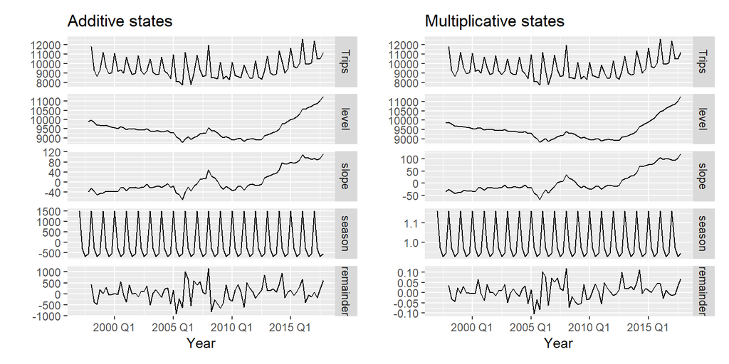

# Holt-Winters damped method

Often the single most accurate forecasting method for seasonal data:

# Holt-Winters with daily data

```r
sth_cross_ped <- pedestrian %>%
  filter(
    Date >= "2016-07-01",
    Sensor == "Southern Cross Station"
  ) %>%
  index_by(Date) %>%
  summarise(Count = sum(Count) / 1000)
sth_cross_ped %>%
  filter(Date <= "2016-07-31") %>%
  model(
    hw = ETS(Count ~ error("M") + trend("Ad") + season("M"))
  ) %>%
  forecast(h = "2 weeks") %>%
  autoplot(sth_cross_ped %>% filter(Date <= "2016-08-14")) +
  labs(
    title = "Daily traffic: Southern Cross",
    y = "Pedestrians ('000)"
  )
```

# Holt-Winters with daily data

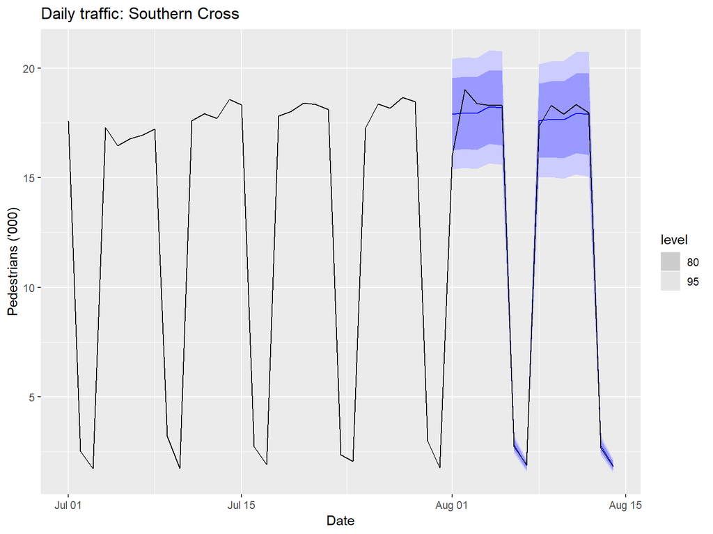

# Innovations state space models

# Exponential smoothing methods

# ETS models

# Additive error models

# Multiplicative error models

# Estimating ETS models

# Innovations state space models

Let $\bm{x}_t = (\ell_t, b_t, s_t, s_{t-1}, \dots, s_{t-m+1})$ and $\varepsilon_t\stackrel{\mbox{\scriptsize iid}}{\sim} \mbox{N}(0,\sigma^2)$.

**Additive errors**

$k(x)=1$.$y_t = \mu_{t} + \varepsilon_t$.

**Multiplicative errors**

$k(\bm{x}_{t-1}) = \mu_{t}$.$y_t = \mu_{t}(1 + \varepsilon_t)$. $\varepsilon_t = (y_t - \mu_t)/\mu_t$ is relative error.

# Innovations state space models

- Estimate parameters $\bm\theta = (\alpha,\beta,\gamma,\phi)$ and initial states $\bm{x}_0 = (\ell_0,b_0,s_0,s_{-1},\dots,s_{-m+1})$ by minimizing $L^*$.

# Parameter restrictions

### *Usual* region

- Traditional restrictions in the methods $0< \alpha,\beta^*,\gamma^*,\phi<1$(equations interpreted as weighted averages).
- In models we set $\beta=\alpha\beta^*$ and $\gamma=(1-\alpha)\gamma^*$.
- Therefore $0< \alpha <1$, $0 < \beta < \alpha$ and $0< \gamma < 1-\alpha$.
- $0.8<\phi<0.98$ — to prevent numerical difficulties.

### *Admissible* region

- To prevent observations in the distant past having a continuing effect on current forecasts.
- Usually (but not always) less restrictive than region.
- For example for ETS(A,N,N): $0< \alpha <1$ while $0< \alpha <2$.

# Model selection

where $L$ is the likelihood and $k$ is the number of parameters initial states estimated in the model.

which is the AIC corrected (for small sample bias).

# AIC and cross-validation

# Automatic forecasting

**From Hyndman et al. (IJF, 2002):**

- Apply each model that is appropriate to the data. Optimize parameters and initial values using MLE (or some other criterion).
- Select best method using AICc:
- Produce forecasts using best method.
- Obtain forecast intervals using underlying state space model.

Method performed very well in M3 competition.

# Example: National populations

```r
fit <- global_economy %>%
  mutate(Pop = Population / 1e6) %>%
  model(ets = ETS(Pop))
fit
```

| Country | ets |
| --- | --- |
| Afghanistan |  |
| Albania |  |
| Algeria |  |
| American Samoa |  |
| Andorra |  |
| Angola |  |
| Antigua and Barbuda |  |
| Arab World |  |
| Argentina |  |
| Armenia |  |

[output cut: 253 more lines]

# Example: National populations

```r
fit %>%
  forecast(h = 5)
```

| Country | .model | Year | Pop | .mean |
| --- | --- | --- | --- | --- |
| Afghanistan | ets | 2018 |  | 3.64e+01 |
| Afghanistan | ets | 2019 |  | 3.73e+01 |
| Afghanistan | ets | 2020 |  | 3.82e+01 |
| Afghanistan | ets | 2021 |  | 3.90e+01 |
| Afghanistan | ets | 2022 |  | 3.99e+01 |
| Albania | ets | 2018 |  | 2.87e+00 |
| Albania | ets | 2019 |  | 2.87e+00 |
| Albania | ets | 2020 |  | 2.87e+00 |
| Albania | ets | 2021 |  | 2.86e+00 |
| Albania | ets | 2022 |  | 2.86e+00 |

[output cut: 1305 more lines]

# Example: Australian holiday tourism

```r
holidays <- tourism %>%
  filter(Purpose == "Holiday")
fit <- holidays %>% model(ets = ETS(Trips))
fit
```

| Region | State | Purpose | ets |
| --- | --- | --- | --- |
| Adelaide | South Australia | Holiday |  |
| Adelaide Hills | South Australia | Holiday |  |
| Alice Springs | Northern Territory | Holiday |  |
| Australia's Coral Coast | Western Australia | Holiday |  |
| Australia's Golden Outback | Western Australia | Holiday |  |
| Australia's North West | Western Australia | Holiday |  |
| Australia's South West | Western Australia | Holiday |  |
| Ballarat | Victoria | Holiday |  |
| Barkly | Northern Territory | Holiday |  |
| Barossa | South Australia | Holiday |  |

[output cut: 66 more lines]

# Example: Australian holiday tourism

```r
fit %>%
  filter(Region == "Snowy Mountains") %>%
  report()
```

```
## Series: Trips
## Model: ETS(M,N,A)
##   Smoothing parameters:
##     alpha = 0.157
##     gamma = 1e-04
##
##   Initial states:
##  l[0] s[0] s[-1] s[-2] s[-3]
##   142  -61   131 -42.2 -27.7
##
##   sigma^2:  0.0388
##
##  AIC AICc  BIC
##  852  854  869
```

# Example: Australian holiday tourism

```r
fit %>%
  filter(Region == "Snowy Mountains") %>%
  components(fit)
```

| Region | State | Purpose | .model | Quarter | Trips | level | season | remainder |
| --- | --- | --- | --- | --- | --- | --- | --- | --- |
| Snowy Mountains | New South Wales | Holiday | ets | 1997 Q1 | NA | NA | -27.7 | NA |
| Snowy Mountains | New South Wales | Holiday | ets | 1997 Q2 | NA | NA | -42.2 | NA |
| Snowy Mountains | New South Wales | Holiday | ets | 1997 Q3 | NA | NA | 130.9 | NA |
| Snowy Mountains | New South Wales | Holiday | ets | 1997 Q4 | NA | 142 | -61.0 | NA |
| Snowy Mountains | New South Wales | Holiday | ets | 1998 Q1 | 101.2 | 140 | -27.7 | -0.11284 |
| Snowy Mountains | New South Wales | Holiday | ets | 1998 Q2 | 112.4 | 142 | -42.2 | 0.15394 |
| Snowy Mountains | New South Wales | Holiday | ets | 1998 Q3 | 310.2 | 148 | 130.9 | 0.13676 |
| Snowy Mountains | New South Wales | Holiday | ets | 1998 Q4 | 89.8 | 148 | -61.0 | 0.03347 |
| Snowy Mountains | New South Wales | Holiday | ets | 1999 Q1 | 112.4 | 147 | -27.7 | -0.06871 |
| Snowy Mountains | New South Wales | Holiday | ets | 1999 Q2 | 102.7 | 147 | -42.2 | -0.01995 |

[output cut: 74 more lines]

# Example: Australian holiday tourism

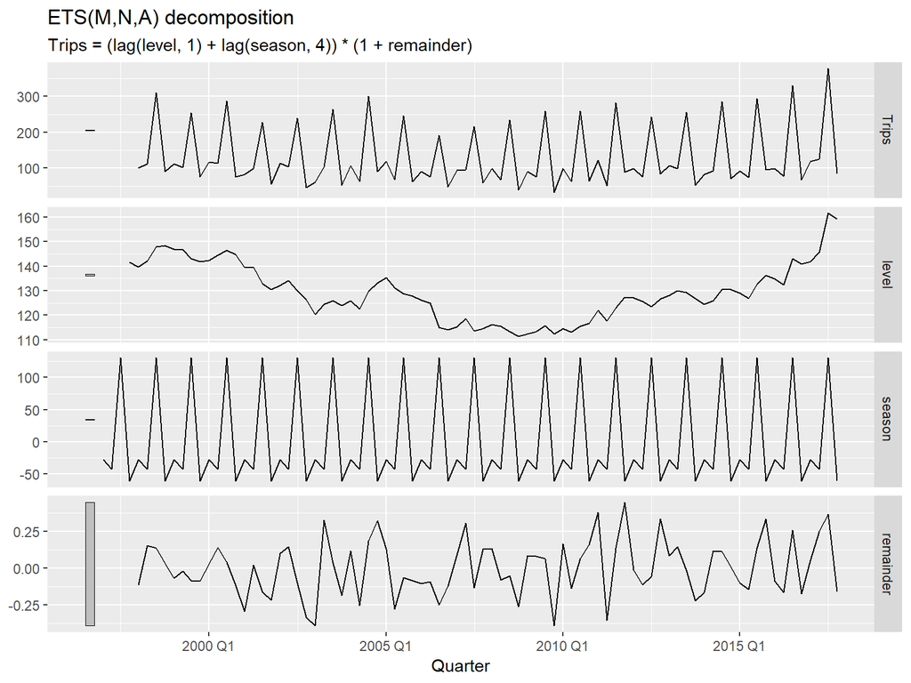

```r
fit %>%
  filter(Region == "Snowy Mountains") %>%
  components(fit) %>%
  autoplot()
```

# Example: Australian holiday tourism

```r
fit %>% forecast()
```

| Region | State | Purpose | .model | Quarter | Trips | .mean |
| --- | --- | --- | --- | --- | --- | --- |
| Adelaide | South Australia | Holiday | ets | 2018 Q1 |  | 210.34 |
| Adelaide | South Australia | Holiday | ets | 2018 Q2 |  | 173.19 |
| Adelaide | South Australia | Holiday | ets | 2018 Q3 |  | 168.92 |
| Adelaide | South Australia | Holiday | ets | 2018 Q4 |  | 185.57 |
| Adelaide | South Australia | Holiday | ets | 2019 Q1 |  | 210.34 |
| Adelaide | South Australia | Holiday | ets | 2019 Q2 |  | 173.19 |
| Adelaide | South Australia | Holiday | ets | 2019 Q3 |  | 168.92 |
| Adelaide | South Australia | Holiday | ets | 2019 Q4 |  | 185.57 |
| Adelaide Hills | South Australia | Holiday | ets | 2018 Q1 |  | 19.39 |
| Adelaide Hills | South Australia | Holiday | ets | 2018 Q2 |  | 19.56 |

[output cut: 598 more lines]

# Example: Australian holiday tourism

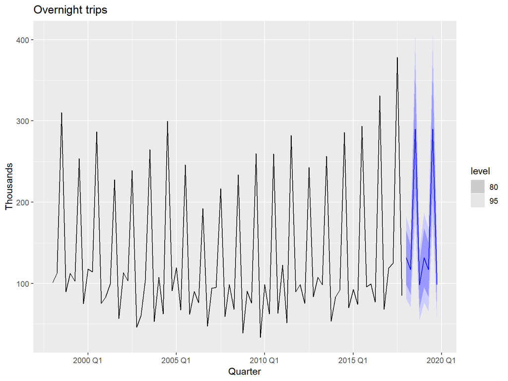

```r
fit %>% forecast() %>%
  filter(Region == "Snowy Mountains") %>%
  autoplot(holidays) +
  labs(y = "Thousands", title = "Overnight trips")
```

# Residuals

### Response residuals

$$\hat{e}_t = y_t -
\hat{y}_{t|t-1}$$

### Innovation residuals

Additive error model:
$$\hat\varepsilon_t
= y_t - \hat{y}_{t|t-1}$$

Multiplicative error model:
$$\hat\varepsilon_t = \frac{y_t -
\hat{y}_{t|t-1}}{\hat{y}_{t|t-1}}$$

# Example: Australian holiday tourism

```r
aus_holidays <- tourism %>%
  filter(Purpose == "Holiday") %>%
  summarise(Trips = sum(Trips))
fit <- aus_holidays %>%
  model(ets = ETS(Trips)) %>%
  report()
```

```
## Series: Trips
## Model: ETS(M,N,M)
##   Smoothing parameters:
##     alpha = 0.358
##     gamma = 0.000969
##
##   Initial states:
##  l[0]  s[0] s[-1] s[-2] s[-3]
##  9667 0.943 0.927 0.968  1.16
##
##   sigma^2:  0.0022
##
##  AIC AICc  BIC
## 1331 1333 1348
```

# Example: Australian holiday tourism

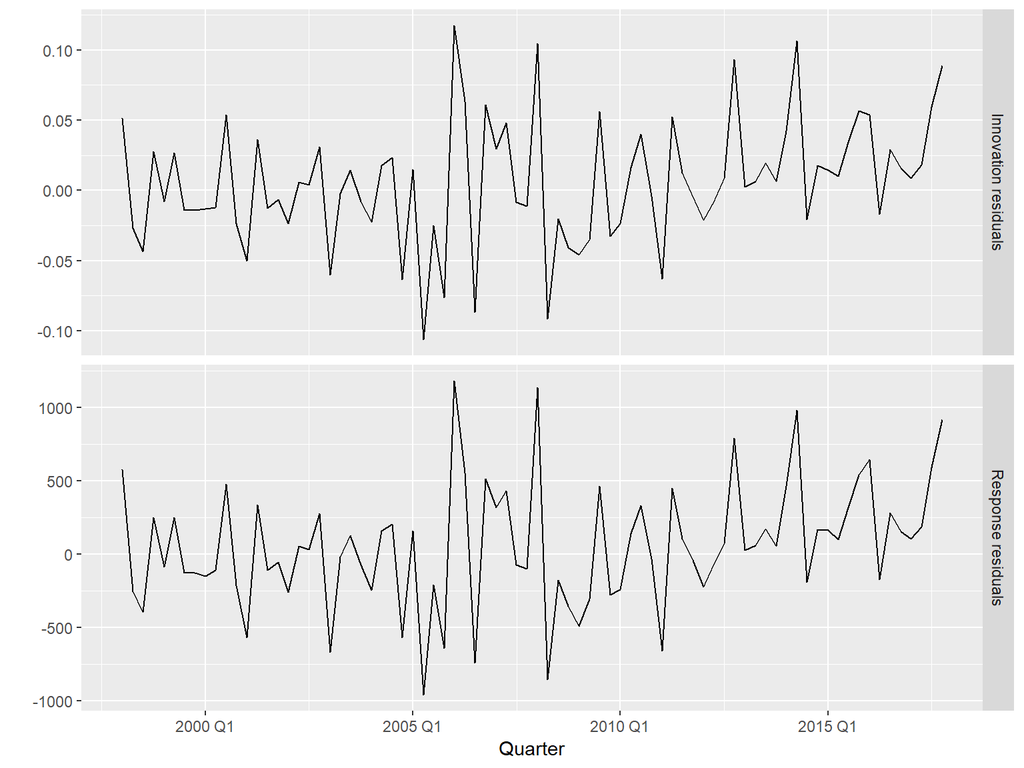

```r
residuals(fit)
residuals(fit, type = "response")
```

# Example: Australian holiday tourism

```r
fit %>%
  augment()
```

| .model | Quarter | Trips | .fitted | .resid | .innov |
| --- | --- | --- | --- | --- | --- |
| ets | 1998 Q1 | 11806 | 11230 | 575.8 | 0.05127 |
| ets | 1998 Q2 | 9276 | 9532 | -256.6 | -0.02692 |
| ets | 1998 Q3 | 8642 | 9036 | -393.3 | -0.04353 |
| ets | 1998 Q4 | 9300 | 9050 | 249.0 | 0.02752 |
| ets | 1999 Q1 | 11172 | 11260 | -88.0 | -0.00781 |
| ets | 1999 Q2 | 9608 | 9358 | 249.2 | 0.02662 |
| ets | 1999 Q3 | 8914 | 9042 | -128.6 | -0.01422 |
| ets | 1999 Q4 | 9026 | 9154 | -128.6 | -0.01405 |
| ets | 2000 Q1 | 11071 | 11221 | -150.2 | -0.01338 |
| ets | 2000 Q2 | 9196 | 9308 | -111.5 | -0.01198 |

[output cut: 70 more lines]

# Some unstable models

- Some of the combinations of (Error, Trend, Seasonal) can lead to numerical difficulties; see equations with division by a state.
- These are: ETS(A,N,M), ETS(A,A,M), ETS(A,A,M).
- Models with multiplicative errors are useful for strictly positive data, but are not numerically stable with data containing zeros or negative values. In that case only the six fully additive models will be applied.

# Exponential smoothing models

# Forecasting with exponential smoothing

# Forecasting with ETS models

iterate the equations for $t=T+1,T+2,\dots,T+h$ and set all $\varepsilon_t=0$ for $t>T$.

- Not the same as $\text{E}(y_{t+h} | \bm{x}_t)$ unless seasonality is additive.
- `fable` uses $\text{E}(y_{t+h} | \bm{x}_t)$.
- Point forecasts for ETS(A,*,*) are identical to ETS(M,*,*) if the parameters are the same.

# Example: ETS(A,A,N)

$$\begin{align*}
y_{T+1} &= \ell_T + b_T + \varepsilon_{T+1}\\
\hat{y}_{T+1|T} & = \ell_{T}+b_{T}\\
y_{T+2} & = \ell_{T+1} + b_{T+1} + \varepsilon_{T+2}\\
& =
(\ell_T + b_T + \alpha\varepsilon_{T+1}) +
(b_T + \beta \varepsilon_{T+1}) +
\varepsilon_{T+2} \\
\hat{y}_{T+2|T} &= \ell_{T}+2b_{T}
\end{align*}$$
etc.

# Example: ETS(M,A,N)

$$\begin{align*}
y_{T+1} &= (\ell_T + b_T )(1+ \varepsilon_{T+1})\\
\hat{y}_{T+1|T} & = \ell_{T}+b_{T}.\\
y_{T+2} & = (\ell_{T+1} + b_{T+1})(1 + \varepsilon_{T+2})\\
& = \left\{
(\ell_T + b_T) (1+ \alpha\varepsilon_{T+1}) +
\left[b_T + \beta (\ell_T +
b_T)\varepsilon_{T+1}\right]
\right\}
(1 + \varepsilon_{T+2}) \\
\hat{y}_{T+2|T} &= \ell_{T}+2b_{T}
\end{align*}$$
etc.

# Forecasting with ETS models

can only be generated using the models.

- The prediction intervals will differ between models with additive and multiplicative errors.
- Exact formulae for some models.
- More general to simulate future sample paths, conditional on the last estimate of the states, and to obtain prediction intervals from the percentiles of these simulated future paths.

# Prediction intervals

# Example: Corticosteroid drug sales

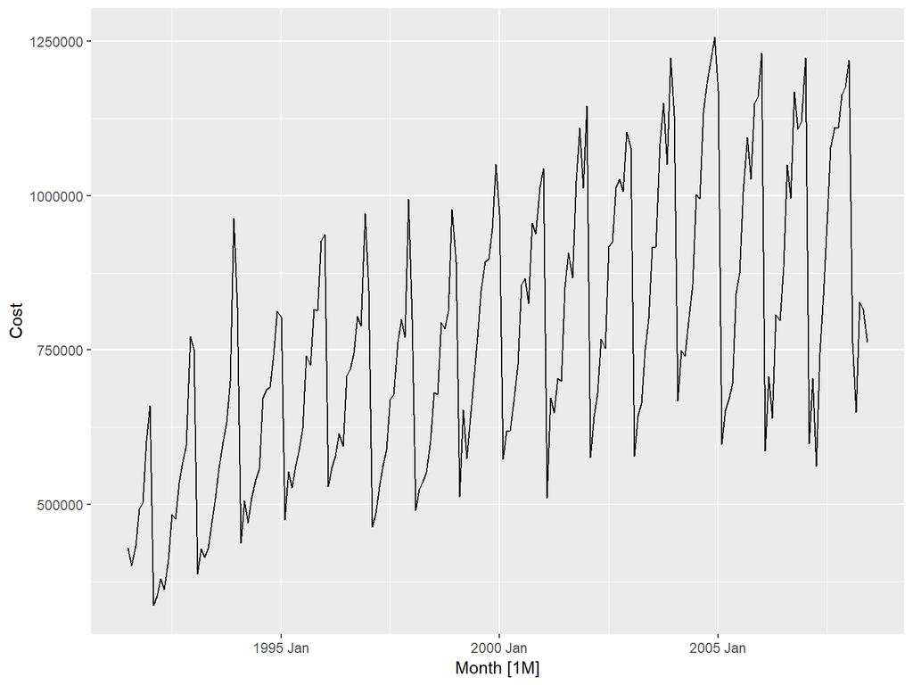

```r
h02 <- PBS %>%
  filter(ATC2 == "H02") %>%
  summarise(Cost = sum(Cost))
h02 %>% autoplot(Cost)
```

# Example: Corticosteroid drug sales

```r
h02 %>%
  model(ETS(Cost)) %>%
  report()
```

```
## Series: Cost
## Model: ETS(M,Ad,M)
##   Smoothing parameters:
##     alpha = 0.307
##     beta  = 0.000101
##     gamma = 0.000101
##     phi   = 0.978
##
##   Initial states:
##    l[0] b[0]  s[0] s[-1] s[-2] s[-3] s[-4] s[-5] s[-6] s[-7] s[-8] s[-9]
##  417269 8206 0.872 0.826 0.756 0.773 0.687  1.28  1.32  1.18  1.16   1.1
##  s[-10] s[-11]
##    1.05  0.981
##
##   sigma^2:  0.0046
##
##  AIC AICc  BIC
## 5515 5519 5575
```

# Example: Corticosteroid drug sales

```r
h02 %>%
  model(ETS(Cost ~ error("A") + trend("A") + season("A"))) %>%
  report()
```

```
## Series: Cost
## Model: ETS(A,A,A)
##   Smoothing parameters:
##     alpha = 0.17
##     beta  = 0.00631
##     gamma = 0.455
##
##   Initial states:
##    l[0] b[0]   s[0]   s[-1]   s[-2]   s[-3]   s[-4]  s[-5]  s[-6]  s[-7]
##  409706 9097 -99075 -136602 -191496 -174531 -241437 210644 244644 145368
##   s[-8] s[-9] s[-10] s[-11]
##  130570 84458  39132 -11674
##
##   sigma^2:  3.5e+09
##
##  AIC AICc  BIC
## 5585 5589 5642
```

# Example: Corticosteroid drug sales

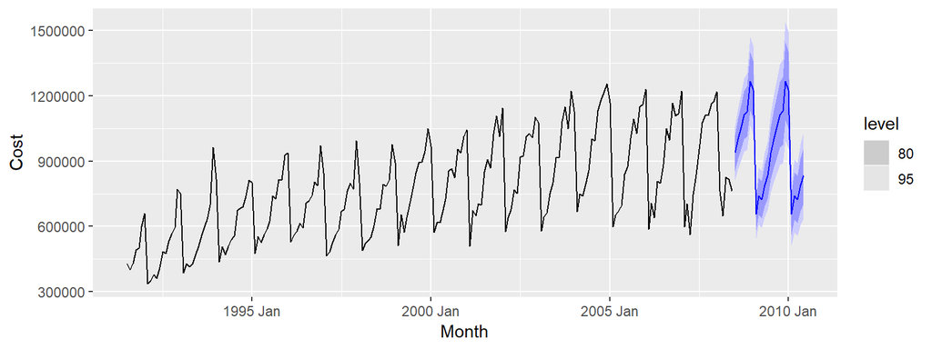

```r
h02 %>%
  model(ETS(Cost)) %>%
  forecast() %>%
  autoplot(h02)
```

# Example: Corticosteroid drug sales

```r
h02 %>%
  model(
    auto = ETS(Cost),
    AAA = ETS(Cost ~ error("A") + trend("A") + season("A"))
  ) %>%
  accuracy()
```

| Model | MAE | RMSE | MAPE | MASE | RMSSE |
| --- | --- | --- | --- | --- | --- |
| auto | 38649 | 51102 | 4.99 | 0.638 | 0.689 |
| AAA | 43378 | 56784 | 6.05 | 0.716 | 0.766 |